# Gapminder - Summarizing with dplyr

# Summarizing the Data

For this section we will be using the dplyr package.

Packages in R are an easy way to import new functions into the program. These functions extend the capabilities of the base program and allow you to analyze data in a more robust fashion.

Documentation on [dplyr](https://dplyr.tidyverse.org/) is located online.

dplyr gives you access to a number of functions that allow you to select, filter, and summarise the data you are examining.

## Filtering

Let’s start with a filtering example.

```r
gapminder %>%
  filter(year == 2007) %>%
  group_by(continent) %>%
  summarise(lifeExp = median(lifeExp))
```

[output not shown]

The %>% is called a pipe operator and allows you to send the results of an expression to the inputs of another expression.

group_by is a useful command to combine rows that have information in common. As you will recall, the gapminder dataset contains an observation for a country, which can be grouped into continents. Each line of the data.frame contains one observation, for a given year, for a given continent.

We can see how many unique countries the data contains, by continent using

```r
gapminder %>%
  group_by(continent) %>%
  summarize(n_obs = n(), n_countries = n_distinct(country))
```

[output not shown]

Both of these examples introduced the summarize command. This command enables you to perform calculations on the variables in the data.frame and return the results.

So the first example

- summarize(lifeExp = median(lifeExp))

led to the median of all of the life expectancy observations, grouped by continent, according to the previous command.

The second example uses 2 new commands for summarizing information.

- n() - which just counts all of the examples, still using the group_by command we had before.
- n_distinct() - which counts the distinct occurrences of a factor. In this case the name of the counties in each of the group_by continents.

# Back to plots - but with pipes and filters

## Histogram

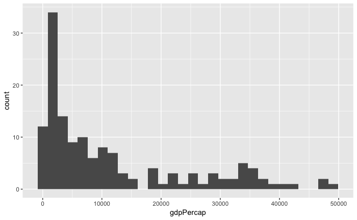

```r
gapminder %>%
  filter(year == 2007) %>%
  ggplot(aes(gdpPercap)) +
  geom_histogram()
```

## Box Plot

```r
gapminder %>%
  filter(year == 2007) %>%
  ggplot(aes(x = continent, y = lifeExp)) +
  geom_boxplot()
```

[output not shown]

## Scatter Plot

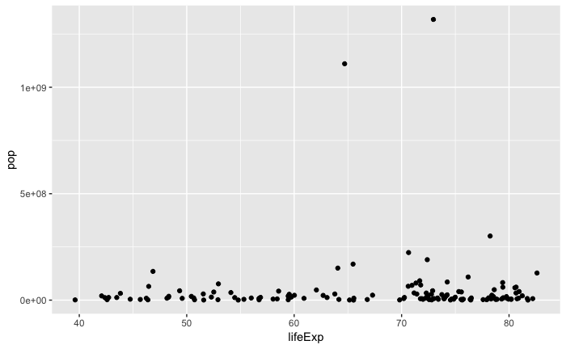

[output not shown]